## Monty Hall Simulation

#### By Brian Hudnall

##### Executive Summary: The Monty Hall problem is a brain teaser, in the form of a probability puzzle (Gruber, Krauss and others), loosely based on the American television game show Let’s Make a Deal. You’re given the choice of three doors: Behind one door is a car; behind the others, goats. You pick a door, say No. 1, and the host, who knows what’s behind the doors, opens another door, say No. 3, which has a goat. He then says to you, “Do you want to pick door No. 2?” Is it to your advantage to switch your choice? Monty_Hall_problem

##### Results: The simulation proves that it’s smarter to switch doors. This was previously proven by Vos Savant. Whose response was that the contestant should switch to the other door.

#### Function creation:

Load the necessary packages used in analysis.

```r
set.seed(42)
library(dplyr)
library(ggplot2)
```

Create a function that simulates the initial choices.

```r
sim_n <- 1000

## This simulates the number of initial choices
sim_initial_choice <- function(n = sim_n) {

        pick <- runif(n)
        ifelse(pick <= 1/3, 'door_1'
               , ifelse(pick <= 2/3, 'door_2', 'door_3'))
}
```

The next function will add two columns, one with an ouput of what the contestant would pick assuming they switch and that the car is behind door #1. The second indicates if their final choice was correct or not.

```r
## This simulates the choice a contestant would make
## assuming the car is behind door #1 and they choose to make a switch
sim_switch_choice <- function(n = sim_n, df = initial_choice_df) {

        df[,2] <- NA; df[,3] <- NA
        names(df)[2:3] <- c("final_choice", "result")
        for(i in 1:n) {
                if(df[i, "initial_choice"] == "door_1") {
                        choice <- runif(1)
                        df[i, "final_choice"] <- ifelse(choice > .50
                               , "door_2"
                               , "door_3")
                        df[i, "result"] <- "goat_given_switch"
                }
                else {
                        df[i, "final_choice"] <- "door_1"
                        df[i, "result"] <- "car_given_switch"
                }
        }
        df
}
```

This next function is very similar to the one above, though it shows the output assuming the contestant stays with their initial door choice.

```r
## This simulates the choice a contestant would make
## assuming the car is behind door #1 and they choose to stay
sim_stay_choice <- function(n = sim_n, df = initial_choice_df) {

        df[,2] <- NA; df[,3] <- NA
        names(df)[2:3] <- c("final_choice", "result")
        for(i in 1:n) {
                choice <- df[i, "initial_choice"]
                if(choice == "door_1") {
                        df[i, "final_choice"] <- "door_1"
                        df[i, "result"] <- "car_given_stay"
                }
                else if(choice == "door_2") {
                        df[i, "final_choice"] <- "door_2"
                        df[i, "result"] <- "goat_given_stay"
                }
                else {
                        df[i, "final_choice"] <- "door_3"
                        df[i, "result"] <- "goat_given_stay"

                }
        }
        df
}
```

This next function will aggregate the count combinations of the first pick, second pick, result, and will then calculate the associated probability of these results.

```r
## summarise the results and return a Data Frame
## also add a column for the probability of results
## given a car or a goat output
result_summary <- function(df, sim_n) {

        df <- df %>%
                count(initial_choice, final_choice, result) %>%
                mutate(prob = n/sim_n) %>%
                mutate

}
```

This function will aggregate the output based on success, fail and show the variance of the result.

```r
result_prob_var <- function(df) {

        df <- as.data.frame(df)
        df <- df %>%
                select(result, n, prob) %>%
                group_by(result) %>%
                summarise_each(funs(sum)) %>%
                mutate(variance = (n * (prob) * (1-prob)))
}
```

This last function will plot the results.

```r
## Plot the initial results
plot_summary <- function(df, title) {

        ggplot(df, aes(x = result, y = prob)) +
                geom_bar(stat = "identity") +
                ggtitle(title)

}
```

#### Run simulation:

We now utilize these functions to simulate and calculate the probability and variance of either staying or switching doors assuming the car is behind door #1.

```r
## run the pick simulation
initial_choice <- sim_initial_choice()

## what are the counts of results in the simulation
## and their probabilities
table(initial_choice)
```

```
## initial_choice
## door_1 door_2 door_3
##    346    329    325
```

```r
table(initial_choice)/sim_n
```

```
## initial_choice
## door_1 door_2 door_3
##  0.346  0.329  0.325
```

```r
## Convert choice list to DataFrame
initial_choice_df <- as.data.frame(initial_choice)

## Run second pick simulation -- either switch or stay
switch_df <- sim_switch_choice(sim_n, initial_choice_df)
stay_df <- sim_stay_choice(sim_n, initial_choice_df)

## Run the result summary function to see the probabilities
## and results
switch_df_agg <- result_summary(switch_df, sim_n)
switch_df_agg
```

```
## Source: local data frame [4 x 5]
## Groups: initial_choice, final_choice
##
##   initial_choice final_choice            result   n  prob
## 1         door_1       door_2 goat_given_switch 179 0.179
## 2         door_1       door_3 goat_given_switch 167 0.167
## 3         door_2       door_1  car_given_switch 329 0.329
## 4         door_3       door_1  car_given_switch 325 0.325
```

```r
stay_df_agg <- result_summary(stay_df, sim_n)
stay_df_agg
```

```
## Source: local data frame [3 x 5]
## Groups: initial_choice, final_choice
##
##   initial_choice final_choice          result   n  prob
## 1         door_1       door_1  car_given_stay 346 0.346
## 2         door_2       door_2 goat_given_stay 329 0.329
## 3         door_3       door_3 goat_given_stay 325 0.325
```

```r
## Show the total probability and variance based on
## picking a car or a goat
switch_df_prob <- result_prob_var(switch_df_agg)
switch_df_prob
```

```
## Source: local data frame [2 x 4]
##
##              result   n  prob  variance
## 1  car_given_switch 654 0.654 147.98974
## 2 goat_given_switch 346 0.346  78.29426
```

```r
stay_df_prob <- result_prob_var(stay_df_agg)
stay_df_prob
```

```
## Source: local data frame [2 x 4]
##
##            result   n  prob  variance
## 1  car_given_stay 346 0.346  78.29426
## 2 goat_given_stay 654 0.654 147.98974
```

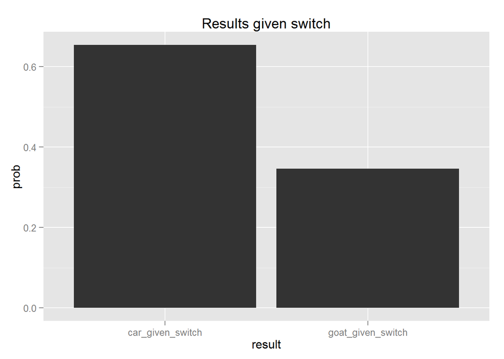

```r
## Plot the results
plot_summary(switch_df_agg, "Results given switch")
```

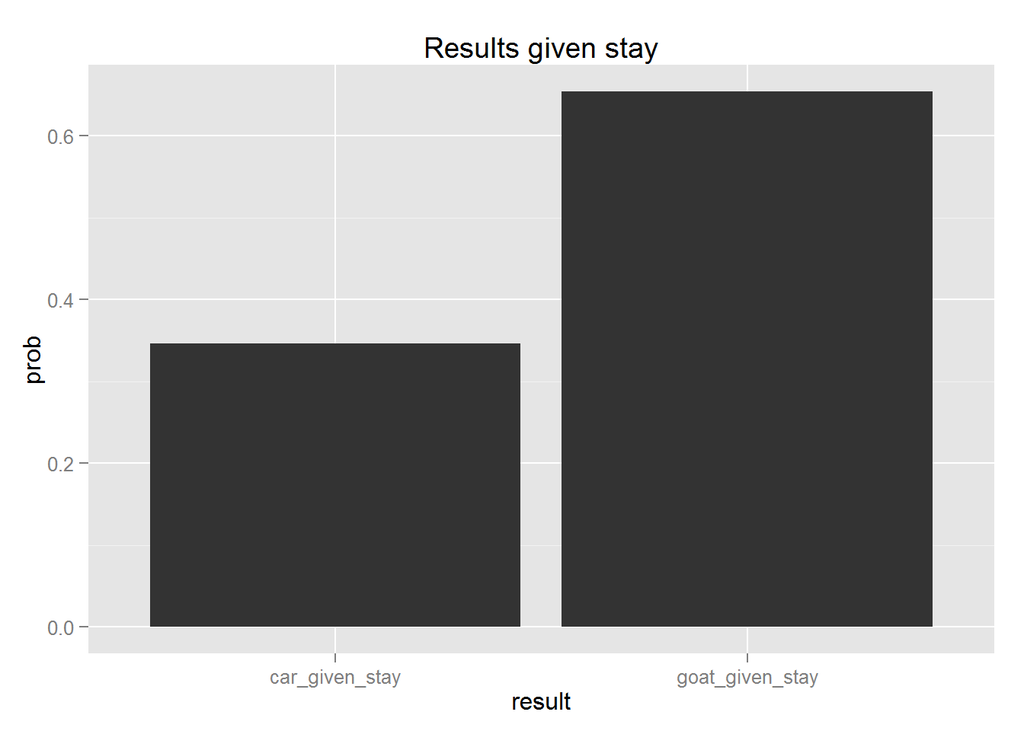

```r
plot_summary(stay_df_agg, "Results given stay")
```